# Practical Machine Learning - Course Project

Saurabh Bhalerao

August 4, 2017

# Prediction Assignment Writeup

## Background

Using devices such as Jawbone Up, Nike FuelBand, and Fitbit is now possible to collect a large amount of data about personal activity relatively inexpensively. These type of devices are part of the quantified self movement - a group of enthusiasts who take measurements about themselves regularly to improve their health, to find patterns in their behavior, or because they are tech geeks. One thing that people regularly do is quantify how much of a particular activity they do, but they rarely quantify how well they do it.

In this project, we will be to use data from accelerometers on the belt, forearm, arm, and dumbell of 6 participant They were asked to perform barbell lifts correctly and incorrectly in 5 different ways. The five ways are exactly according to the specification (Class A), throwing the elbows to the front (Class B), lifting the dumbbell only halfway (Class C), lowering the dumbbell only halfway (Class D) and throwing the hips to the front (Class E). Only Class A corresponds to correct performance. The goal of this project is to predict the manner in which they did the exercise, i.e., Class A to E. More information is available from the website here: http://groupware.les.inf.puc-rio.br/har (see the section on the Weight Lifting Exercise Dataset).

## Data Processing

### Import the Data

First,Uploading R libraries.

```r
library(caret)
```

```r
library(rpart)
library(rpart.plot)
library(lattice)
library(ggplot2)
library(rattle)
library(randomForest)
library(corrplot)
```

### Data Loading & Cleaning

```r
#set URL for Download
trainUrl <- "http://d396qusza40orc.cloudfront.net/predmachlearn/pml-training.csv"
testUrl <- "http://d396qusza40orc.cloudfront.net/predmachlearn/pml-testing.csv"

#download the data set
training <- read.csv(url(trainUrl), na.strings = c("NA", ""))
testing <- read.csv(url(testUrl), na.strings = c("NA", ""))

#Partition training data into two data sets: Train (60%) & Test (40%)
inTrain <- createDataPartition(y=training$classe, p=0.6, list=FALSE)
myTraining <- training[inTrain, ]; myTesting <- training[-inTrain, ]
dim(myTraining); dim(myTesting)
```

```
## [1] 11776   160
```

```
## [1] 7846  160
```

### Cleaning Data

```r
# Cleaning NearZeroVariance Variables
nzv <- nearZeroVar(myTraining, saveMetrics=TRUE)
myTraining <- myTraining[,nzv$nzv==FALSE]
myTesting <- myTesting[,nzv$nzv==FALSE]
dim(myTraining);dim(myTesting)
```

```
## [1] 11776   124
```

```
## [1] 7846  124
```

```r
# Remove the columns with more NA values
AllNA    <- sapply(myTraining, function(x) mean(is.na(x))) > 0.95
myTraining <- myTraining[, AllNA==FALSE]
myTesting  <- myTesting[, AllNA==FALSE]
dim(myTraining);dim(myTesting)
```

```
## [1] 11776    59
```

```
## [1] 7846   59
```

```r
# Remove first 5 columns
myTraining <- myTraining[, -(1:5)]
myTesting  <- myTesting[, -(1:5)]
dim(myTraining);dim(myTesting)
```

```
## [1] 11776    54
```

```
## [1] 7846   54
```

## Prediction Model

Three methods will be applied to model the regressions (in the Train dataset) and the best one (with higher accuracy when applied to the Test dataset) will be used for the quiz predictions. The methods are: Random Forests, Decision Tree and Generalized Boosted Model, as described below.

## 1) Random Forest

```r
# model fit
set.seed(12345)
controlRF <- trainControl(method="cv", number=3, verboseIter=FALSE)
modFitRandForest <- train(classe ~ ., data=myTraining, method="rf",trControl=controlRF)
modFitRandForest$finalModel
```

```
##
## Call:
##  randomForest(x = x, y = y, mtry = param$mtry)
##                Type of random forest: classification
##                      Number of trees: 500
## No. of variables tried at each split: 27
##
##         OOB estimate of  error rate: 0.32%
## Confusion matrix:
##      A    B    C    D    E  class.error
## A 3347    0    0    0    1 0.0002986858
## B    7 2268    3    1    0 0.0048266784
## C    0    8 2046    0    0 0.0038948393
## D    0    0   11 1918    1 0.0062176166
## E    0    1    0    5 2159 0.0027713626
```

### Prediction using above model & check of accuracy

```r
predictRandForest <- predict(modFitRandForest,myTesting)
confMatRandForest <- confusionMatrix(predictRandForest, myTesting$classe)
confMatRandForest
```

```
## Confusion Matrix and Statistics
##
##           Reference
## Prediction    A    B    C    D    E
##          A 2232    8    0    0    0
##          B    0 1509   10    0    0
##          C    0    1 1357    1    0
##          D    0    0    1 1284    3
##          E    0    0    0    1 1439
##
## Overall Statistics
##
##                Accuracy : 0.9968
##                  95% CI : (0.9953, 0.9979)
##     No Information Rate : 0.2845
##     P-Value [Acc > NIR] : < 2.2e-16
##
##                   Kappa : 0.996
##  Mcnemar's Test P-Value : NA
##
## Statistics by Class:
##
##                      Class: A Class: B Class: C Class: D Class: E
## Sensitivity            1.0000   0.9941   0.9920   0.9984   0.9979
## Specificity            0.9986   0.9984   0.9997   0.9994   0.9998
## Pos Pred Value         0.9964   0.9934   0.9985   0.9969   0.9993
## Neg Pred Value         1.0000   0.9986   0.9983   0.9997   0.9995
## Prevalence             0.2845   0.1935   0.1744   0.1639   0.1838
## Detection Rate         0.2845   0.1923   0.1730   0.1637   0.1834
## Detection Prevalence   0.2855   0.1936   0.1732   0.1642   0.1835
## Balanced Accuracy      0.9993   0.9962   0.9958   0.9989   0.9989
```

## 2) Decision Trees

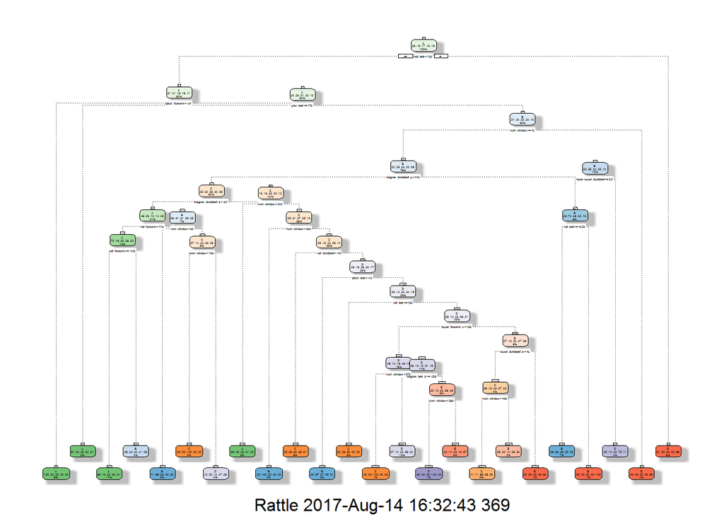

```r
# model fit
set.seed(12345)
modFitDecTree <- rpart(classe ~ ., data=myTraining, method="class")
fancyRpartPlot(modFitDecTree)
```

### Prediction on test data and checking accuracy of model

```r
predictDecTree <- predict(modFitDecTree, newdata=myTesting, type="class")
confMatDecTree <- confusionMatrix(predictDecTree, myTesting$classe)
confMatDecTree
```

```
## Confusion Matrix and Statistics
##
##           Reference
## Prediction    A    B    C    D    E
##          A 1971  165   39   44   16
##          B   80  991   73   77   41
##          C   41   78  991   75    8
##          D  115  220  236  995   92
##          E   25   64   29   95 1285
##
## Overall Statistics
##
##                Accuracy : 0.7944
##                  95% CI : (0.7853, 0.8033)
##     No Information Rate : 0.2845
##     P-Value [Acc > NIR] : < 2.2e-16
##
##                   Kappa : 0.7403
##  Mcnemar's Test P-Value : < 2.2e-16
##
## Statistics by Class:
##
##                      Class: A Class: B Class: C Class: D Class: E
## Sensitivity            0.8831   0.6528   0.7244   0.7737   0.8911
## Specificity            0.9530   0.9572   0.9688   0.8989   0.9667
## Pos Pred Value         0.8819   0.7853   0.8307   0.6001   0.8578
## Neg Pred Value         0.9535   0.9200   0.9433   0.9530   0.9753
## Prevalence             0.2845   0.1935   0.1744   0.1639   0.1838
## Detection Rate         0.2512   0.1263   0.1263   0.1268   0.1638
## Detection Prevalence   0.2849   0.1608   0.1521   0.2113   0.1909
## Balanced Accuracy      0.9180   0.8050   0.8466   0.8363   0.9289
```

## 3) Generalized Boosted Method

```r
# model fit
set.seed(12345)
controlGBM <- trainControl(method = "repeatedcv", number = 5, repeats = 1)
modFitGBM  <- train(classe ~ ., data=myTraining, method = "gbm",
                    trControl = controlGBM, verbose = FALSE)
modFitGBM$finalModel
```

```
## A gradient boosted model with multinomial loss function.
## 150 iterations were performed.
## There were 53 predictors of which 45 had non-zero influence.
```

### Prediction on test data and checking accuracy of model

```r
predictGBM <- predict(modFitGBM, newdata=myTesting)
confMatGBM <- confusionMatrix(predictGBM, myTesting$classe)
confMatGBM
```

```
## Confusion Matrix and Statistics
##
##           Reference
## Prediction    A    B    C    D    E
##          A 2222   21    0    0    0
##          B    8 1485   20   13    8
##          C    0   11 1345   13    2
##          D    2    1    2 1256   12
##          E    0    0    1    4 1420
##
## Overall Statistics
##
##                Accuracy : 0.985
##                  95% CI : (0.982, 0.9875)
##     No Information Rate : 0.2845
##     P-Value [Acc > NIR] : < 2.2e-16
##
##                   Kappa : 0.981
##  Mcnemar's Test P-Value : NA
##
## Statistics by Class:
##
##                      Class: A Class: B Class: C Class: D Class: E
## Sensitivity            0.9955   0.9783   0.9832   0.9767   0.9847
## Specificity            0.9963   0.9923   0.9960   0.9974   0.9992
## Pos Pred Value         0.9906   0.9681   0.9810   0.9866   0.9965
## Neg Pred Value         0.9982   0.9948   0.9964   0.9954   0.9966
## Prevalence             0.2845   0.1935   0.1744   0.1639   0.1838
## Detection Rate         0.2832   0.1893   0.1714   0.1601   0.1810
## Detection Prevalence   0.2859   0.1955   0.1747   0.1622   0.1816
## Balanced Accuracy      0.9959   0.9853   0.9896   0.9870   0.9920
```

## Predicting on Testing set

```r
(predict(modFitRandForest, testing))
```

```
##  [1] B A B A A E D B A A B C B A E E A B B B
## Levels: A B C D E
```